# Chapter 4

Author

Daiil Jun

Modified

Invalid Date

```r
library(tidyverse)
library(cmdstanr)
library(tidybayes)
library(bayesplot)
library(patchwork)
```

```r
df <- read_csv("https://raw.githubusercontent.com/MatsuuraKentaro/Bayesian_Statistical_Modeling_with_Stan_R_and_Python/refs/heads/master/chap04/input/data-salary.csv")
```

###4.1.2 Check Data Distribution

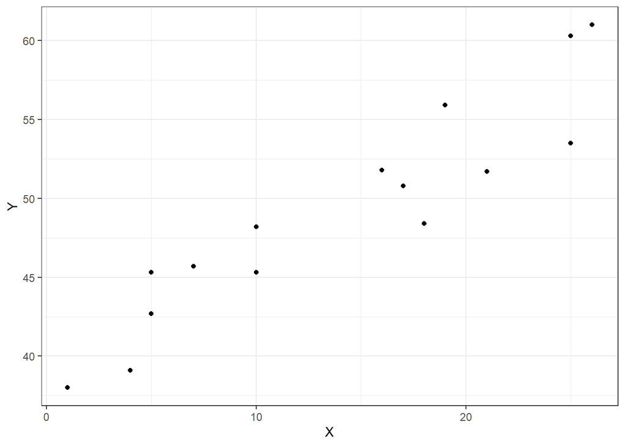

```r
ggplot(df, aes(x = X, y = Y)) +
  geom_point() +
  theme_bw()
```

###4.1.3 Describe Model Formula

$$\begin{aligned}
Y[n] = y_{base}[n] + \epsilon[n] && n = 1,...,N \\
y_{base}[n] = a + bX[n] && n = 1,...,N \\
\epsilon[n] \sim N(0, \sigma) && n = 1,...,N
\end{aligned}$$

###4.1.4 Maximum Likelihood Estimation using R

```r
res_lm <- lm(Y ~ X, data = df)
res_lm
```

```
Call:
lm(formula = Y ~ X, data = df)

Coefficients:
(Intercept)            X
    38.6969       0.7524
```

```r
x_pred <- tibble(X = 0:28)

conf_95 <- predict(res_lm, x_pred, interval = "confidence", level = 0.95) |>
  as_tibble() |>
  rename(conf_lwr = lwr, conf_upr = upr) |>
  select(-fit)

pred_95 <- predict(res_lm, x_pred, interval = "prediction", level = 0.95) |>
  as_tibble() |>
  rename(pred_lwr = lwr, pred_upr = upr)
```

```r
plot_df <- bind_cols(x_pred, conf_95, pred_95)
```

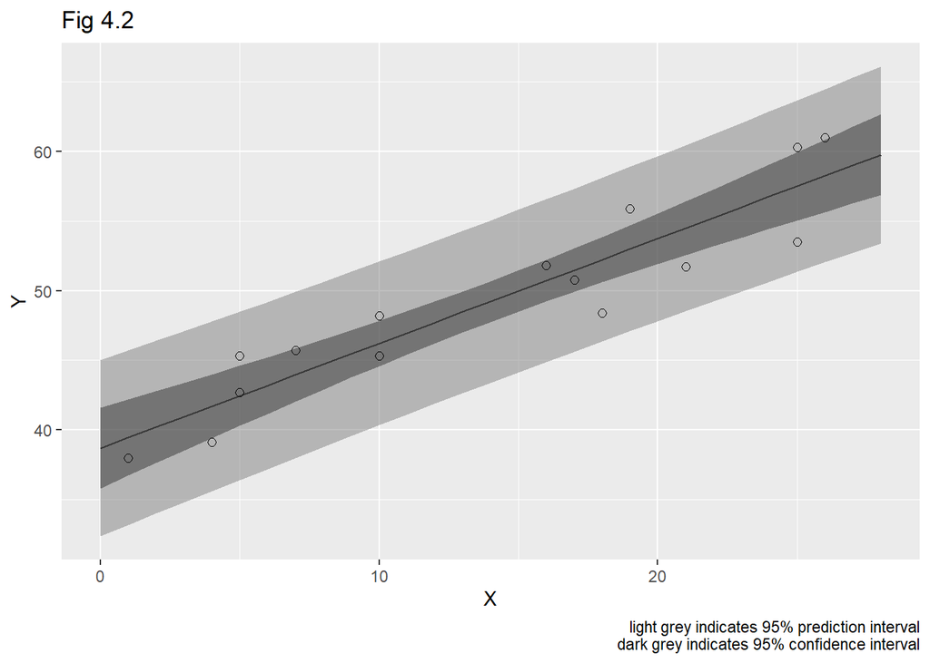

```r
ggplot(plot_df, aes(x = X, y = fit)) +
  geom_line() +
  geom_ribbon(aes(ymin = pred_lwr, ymax = pred_upr),
              fill = "grey50", alpha = 0.5) +
  geom_ribbon(aes(ymin = conf_lwr, ymax = conf_upr),
              fill = "grey20", alpha = 0.5) +
  geom_point(data = df, aes(x = X, y = Y), size = 2, shape = 1) +
  ylab("Y") +
  xlab("X") +
  labs(
    title = "Fig 4.2",
    caption = "light grey indicates 95% prediction interval
                dark grey indicates 95% confidence interval"
    )
```

### 4.1.5 Implement the Model with Stan

```r
data <- list(N = nrow(df), X = df$X, Y = df$Y)

model <- cmdstan_model(stan_file = "model/model4-4.stan")

fit <- model$sample(data = data, seed = 123, refresh = 1000)
```

```
Running MCMC with 4 sequential chains...

Chain 1 Iteration:    1 / 2000 [  0%]  (Warmup)
Chain 1 Iteration: 1000 / 2000 [ 50%]  (Warmup)
Chain 1 Iteration: 1001 / 2000 [ 50%]  (Sampling)
Chain 1 Iteration: 2000 / 2000 [100%]  (Sampling)
Chain 1 finished in 0.1 seconds.
Chain 2 Iteration:    1 / 2000 [  0%]  (Warmup)
Chain 2 Iteration: 1000 / 2000 [ 50%]  (Warmup)
Chain 2 Iteration: 1001 / 2000 [ 50%]  (Sampling)
Chain 2 Iteration: 2000 / 2000 [100%]  (Sampling)
Chain 2 finished in 0.0 seconds.
Chain 3 Iteration:    1 / 2000 [  0%]  (Warmup)
Chain 3 Iteration: 1000 / 2000 [ 50%]  (Warmup)
Chain 3 Iteration: 1001 / 2000 [ 50%]  (Sampling)
Chain 3 Iteration: 2000 / 2000 [100%]  (Sampling)
Chain 3 finished in 0.1 seconds.
Chain 4 Iteration:    1 / 2000 [  0%]  (Warmup)
Chain 4 Iteration: 1000 / 2000 [ 50%]  (Warmup)
Chain 4 Iteration: 1001 / 2000 [ 50%]  (Sampling)
Chain 4 Iteration: 2000 / 2000 [100%]  (Sampling)
Chain 4 finished in 0.1 seconds.

All 4 chains finished successfully.
Mean chain execution time: 0.1 seconds.
Total execution time: 1.4 seconds.
```

```r
fit$cmdstan_summary()
```

```
Inference for Stan model: model4_4_model
4 chains: each with iter=1000; warmup=1000; thin=1; 1000 iterations saved.

Warmup took (0.026, 0.016, 0.031, 0.022) seconds, 0.095 seconds total
Sampling took (0.040, 0.022, 0.042, 0.037) seconds, 0.14 seconds total

                Mean     MCSE  StdDev    MAD    5%   50%   95%  ESS_bulk  ESS_tail  R_hat

lp__             -22  4.4e-02     1.4    1.1   -24   -21   -20      1139      1318    1.0
accept_stat__   0.89    0.031    0.17  0.060  0.52  0.96   1.0       124       262    1.0
stepsize__      0.38      nan   0.053  0.073  0.31  0.38  0.45       nan       nan    nan
treedepth__      2.7    0.085    0.75    1.5   2.0   3.0   4.0       192       171    1.0
n_leapfrog__     8.3     0.73     4.4    5.9   3.0   7.0    15       115       116    1.0
divergent__     0.00      nan    0.00   0.00  0.00  0.00  0.00       nan       nan    nan
energy__          23    0.059     1.8    1.7    21    23    27      1079      1271    1.0

a                 39  4.1e-02     1.6    1.4    36    39    41      1479      1188    1.0
b               0.75  2.5e-03   0.096  0.087  0.60  0.75  0.91      1535      1134    1.0
sigma            2.9  1.6e-02    0.65   0.57   2.0   2.8   4.1      1584      1475    1.0

Samples were drawn using hmc with nuts.
For each parameter, ESS_bulk and ESS_tail measure the effective sample size for the entire sample (bulk) and for the .05 and .95 tails (tail),
and R_hat measures the potential scale reduction on split chains. At convergence R_hat will be very close to 1.00.
```

###4.2.3 Save the Estimation Result

```r
fit$save_object(file = "output/result-model4-4.rds")
```

`bayesplot` package provides a simple way to make MCMC plots but limited in customization.

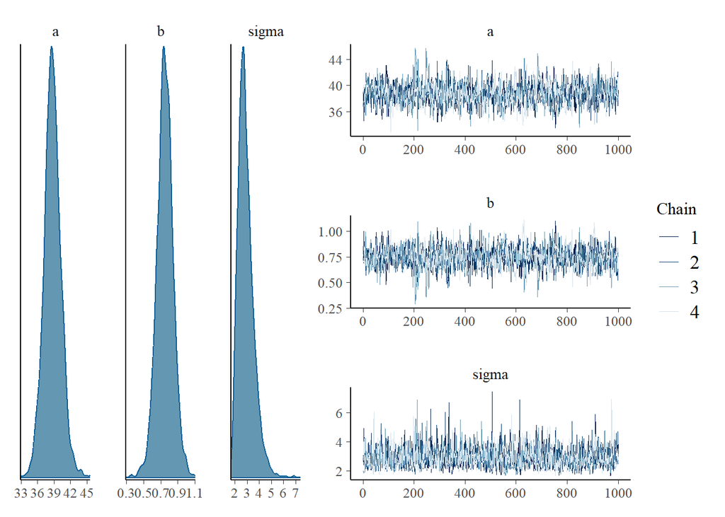

```r
draws_array <- fit$draws(variables = c("a", "b", "sigma"))

trace_p <- mcmc_trace(draws_array, facet_args = list(ncol = 1))

dense_p <- mcmc_dens(draws_array, )

dense_p + trace_p
```

Using `tidybayes` and `ggplot2` can customize plots. But more hassle.

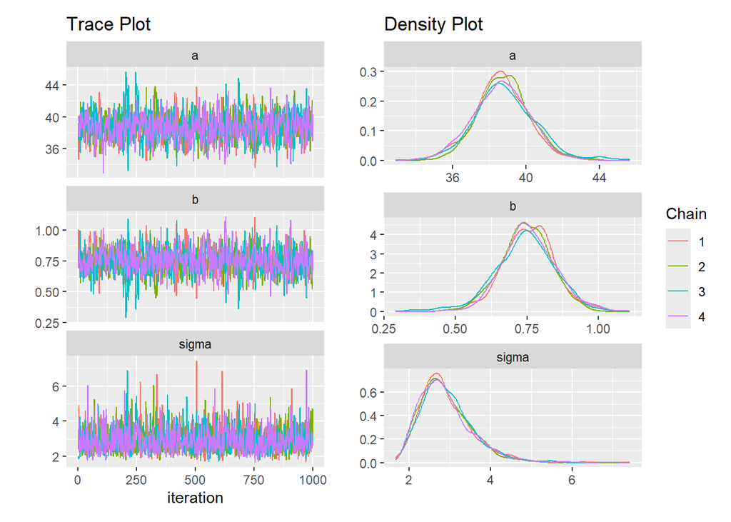

```r
draws_tidy <- fit |>
  gather_draws(a, b, sigma)

trace_tidy <- ggplot(draws_tidy, aes(x = .iteration, y = .value, color = factor(.chain))) +
  geom_line() +
  facet_wrap(~ .variable, scales = "free_y", ncol = 1) +
  ylab("") +
  xlab("iteration") +
  labs(
    title = "Trace Plot"
  ) +
  scale_color_discrete(
    name = "Chain"
  )

dens_tidy <- ggplot(draws_tidy, aes(x = .value, color = factor(.chain))) +
  geom_density() +
  facet_wrap(~ .variable, scales = "free", ncol = 1) +
  theme(legend.position = "none") +
  ylab("") +
  xlab("") +
  labs(
    title = "Density Plot"
  )

trace_tidy + dens_tidy +
  plot_layout(guides = "collect")
```

### 4.2.4 Adjust the settings of MCMC

Changing initial values

```r
init_fun <- function(chain_id) {
  set.seed(chain_id)
  list(
    a = runif(1,min = 30, max = 50),
    b = rnorm(1, 0, 2),
    sigma = runif(1, min = 2, max = 5)
    )
}

fit <- model$sample(
  data = data,
  seed = 123,
  init = init_fun,
  chains = 3,
  iter_warmup = 500,
  iter_sampling = 500,
  thin = 2,
  parallel_chains = 3,
  save_warmup = TRUE,
  refresh = 500
)
```

```
Running MCMC with 3 parallel chains...

Chain 1 Iteration:   1 / 1000 [  0%]  (Warmup)
Chain 1 Iteration: 500 / 1000 [ 50%]  (Warmup)
Chain 1 Iteration: 501 / 1000 [ 50%]  (Sampling)
Chain 1 Iteration: 1000 / 1000 [100%]  (Sampling)
Chain 2 Iteration:   1 / 1000 [  0%]  (Warmup)
Chain 2 Iteration: 500 / 1000 [ 50%]  (Warmup)
Chain 2 Iteration: 501 / 1000 [ 50%]  (Sampling)
Chain 2 Iteration: 1000 / 1000 [100%]  (Sampling)
Chain 1 finished in 0.0 seconds.
Chain 2 finished in 0.0 seconds.
Chain 3 Iteration:   1 / 1000 [  0%]  (Warmup)
Chain 3 Iteration: 500 / 1000 [ 50%]  (Warmup)
Chain 3 Iteration: 501 / 1000 [ 50%]  (Sampling)
Chain 3 Iteration: 1000 / 1000 [100%]  (Sampling)
Chain 3 finished in 0.0 seconds.

All 3 chains finished successfully.
Mean chain execution time: 0.0 seconds.
Total execution time: 0.4 seconds.
```

Within-chain parallelization requires setting threads when compiling the model before sampling.

```r
model_threading <- cmdstan_model(
  stan_file = "model/model4-4.stan",
  cpp_options = list(stan_threads = TRUE)
  )

fit_thread <- model_threading$sample(
  data = data,
  seed = 123,
  init = init_fun,
  chains = 3,
  iter_warmup = 500,
  iter_sampling = 500,
  thin = 2,
  parallel_chains = 3,
  threads_per_chain = 2,
  save_warmup = TRUE,
  refresh = 500
)
```

```
Running MCMC with 3 parallel chains, with 2 thread(s) per chain...

Chain 1 Iteration:   1 / 1000 [  0%]  (Warmup)
Chain 1 Iteration: 500 / 1000 [ 50%]  (Warmup)
Chain 1 Iteration: 501 / 1000 [ 50%]  (Sampling)
Chain 1 Iteration: 1000 / 1000 [100%]  (Sampling)
Chain 2 Iteration:   1 / 1000 [  0%]  (Warmup)
Chain 2 Iteration: 500 / 1000 [ 50%]  (Warmup)
Chain 2 Iteration: 501 / 1000 [ 50%]  (Sampling)
Chain 2 Iteration: 1000 / 1000 [100%]  (Sampling)
Chain 3 Iteration:   1 / 1000 [  0%]  (Warmup)
Chain 3 Iteration: 500 / 1000 [ 50%]  (Warmup)
Chain 3 Iteration: 501 / 1000 [ 50%]  (Sampling)
Chain 3 Iteration: 1000 / 1000 [100%]  (Sampling)
Chain 1 finished in 0.0 seconds.
Chain 2 finished in 0.0 seconds.
Chain 3 finished in 0.0 seconds.

All 3 chains finished successfully.
Mean chain execution time: 0.0 seconds.
Total execution time: 0.3 seconds.
```

### 4.2.5 Draw the MCMC sample

```r
d_ms <- fit$draws(format = "df") #using cmdstanr function

d_tidy <- tidy_draws(fit) #using tidybayes
```

### 4.2.6 Joint Posterior Distributions

The generated MCMC sample is the draws from the posterior distribution, which is the joint distribution of a, b, and $/sigma$

```r
d_ms
```

```
# A draws_df: 250 iterations, 3 chains, and 4 variables
   lp__  a    b sigma
1   -22 37 0.86   3.9
2   -21 38 0.84   3.1
3   -26 34 0.89   3.3
4   -23 36 0.93   3.7
5   -23 41 0.63   2.0
6   -24 40 0.63   2.0
7   -22 40 0.70   3.7
8   -20 39 0.72   2.9
9   -20 39 0.72   2.4
10  -21 38 0.79   2.9
# ... with 740 more draws
# ... hidden reserved variables {'.chain', '.iteration', '.draw'}
```

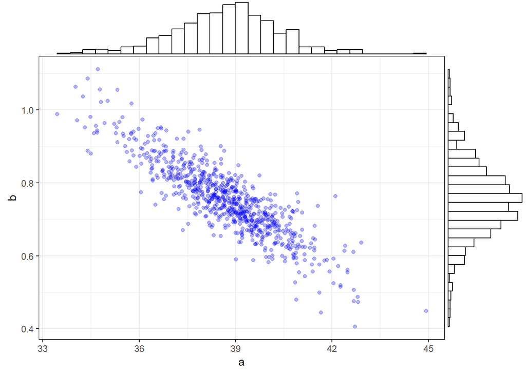

```r
draws_wide <- fit |>
  spread_draws(a, b)

p_center <- ggplot(draws_wide, aes(x = a, y = b)) +
  geom_point(alpha = 0.3, color = "blue") +
  theme_bw()

ggExtra::ggMarginal(p_center, type = "histogram", fill = "white")
```

### 4.2.7 Byaesian Confidence Intervals and Bayesian Prediction Intervals

```r
N_ms <- nrow(d_ms)

y10_base <- d_ms$a + d_ms$b * 10 #x = 10, 10 years of experience
y10_pred <- rnorm(n = N_ms, mean = y10_base, sd = d_ms$sigma)
```

Figure 4.8

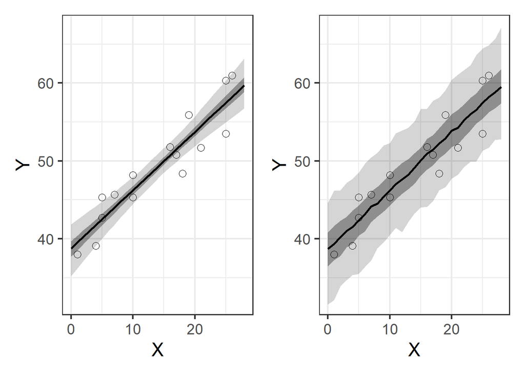

```r
Xp <- seq(0, 28, by = 1)
Np <- length(Xp)

yp_base_ms <- matrix(nrow=N_ms, ncol=Np)

yp_ms <- matrix(nrow=N_ms, ncol=Np)


for (n in 1:Np) {
  yp_base_ms[,n] <- d_ms$a + d_ms$b * Xp[n] #confidence interval not incorporating randomness
  yp_ms[,n] <- rnorm(n=N_ms, mean=yp_base_ms[,n], sd=d_ms$sigma) #prediction interval
}

qua <- apply(yp_base_ms, 2, quantile, probs = c(0.025, 0.25, 0.5, 0.75, 0.975)) #calculate quantile for each Xp



d_est <- data.frame(
  X = Xp,
  t(qua), #transpose of qua
  check.names = FALSE
  )

qua_pred <- apply(yp_ms, 2, quantile, probs = c(0.025, 0.25, 0.5, 0.75, 0.975))

d_pred <- data.frame(
  X = Xp,
  t(qua_pred),
  check.names = FALSE
)

fig_left <- ggplot() +
  theme_bw(base_size=18) +
  geom_ribbon(data=d_est, aes(x=X, ymin=`2.5%`, ymax=`97.5%`), fill='black', alpha=1/6) +
  geom_ribbon(data=d_est, aes(x=X, ymin=`25%`, ymax=`75%`), fill='black', alpha=2/6) +
  geom_line(data=d_est, aes(x=X, y=`50%`), linewidth=1) +
  geom_point(data=df, aes(x=X, y=Y), shape=1, size=3) +
  coord_cartesian(ylim = c(32, 67)) +
  scale_y_continuous(breaks=seq(40, 60, 10)) +
  labs(y='Y')

fig_right <- ggplot() +
  theme_bw(base_size=18) +
  geom_ribbon(data=d_pred, aes(x=X, ymin=`2.5%`, ymax=`97.5%`), fill='black', alpha=1/6) +
  geom_ribbon(data=d_pred, aes(x=X, ymin=`25%`, ymax=`75%`), fill='black', alpha=2/6) +
  geom_line(data=d_pred, aes(x=X, y=`50%`), linewidth=1) +
  geom_point(data=df, aes(x=X, y=Y), shape=1, size=3) +
  coord_cartesian(ylim = c(32, 67)) +
  scale_y_continuous(breaks=seq(40, 60, 10)) +
  labs(y='Y')

fig_left | fig_right
```

### 4.3 `transformed parameters` Block and `generated quantities` Block

### 4.5 Exercises

```r
set.seed(123)
N1 <- 30
N2 <- 20
Y1 <- rnorm(n = N1, mean = 0, sd = 5)
Y2 <- rnorm(n = N2, mean = 1, sd = 4)

df <- tibble(
  id = 1:50,
  value = c(Y1, Y2),
  group = c(rep("Y1", 30), rep("Y2", 20))
)
```

1. Visualize the data from these two groups so that we can intuitively see whether the difference exists between them.

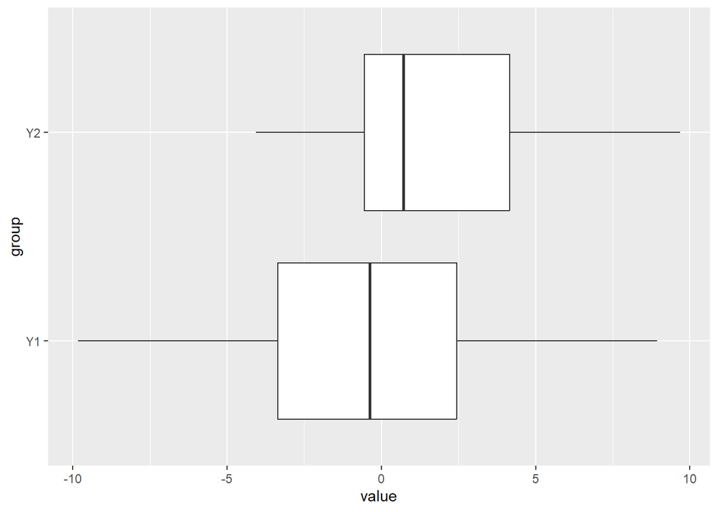

```r
ggplot(df, aes(x = value, y = group)) +
  geom_boxplot()
```

```r
t.test(value ~ group, data = df)
```

```
    Welch Two Sample t-test

data:  value by group
t = -1.5884, df = 47.914, p-value = 0.1188
alternative hypothesis: true difference in means between group Y1 and group Y2 is not equal to 0
95 percent confidence interval:
 -4.2195205  0.4951669
sample estimates:
mean in group Y1 mean in group Y2
      -0.2355188        1.6266580
```

3. Create the model ile of (2) in Stan and estimate the parameters. Don’t use generated quantities block here yet, because in the next (4) we will be practicing how to make use of draws from R or Python.

```stan
data {
  int<lower=0> N1;
  int<lower=0> N2;
  vector[N1] Y1;
  vector[N2] Y2;
}


parameters {
  real mu1;
  real mu2;
  real<lower = 0> sigma;
}


model {

  Y1[1:N1] ~ normal(mu1, sigma);
  Y2[1:N2] ~ normal(mu2, sigma);

}
```

```r
stan_data <- list(
  N1 = N1,
  N2 = N2,
  Y1 = Y1,
  Y2 = Y2
)
```

4. Compute from the obtained draws using R or Python (hint: we can count how many times the event occurrs in the entire draws, and divide this quantity by the total number of draws).

```r
model_equal <- cmdstan_model("model/model4-exercise.stan")
fit_equal <- model_equal$sample(data = stan_data, seed = 123)
```

```
Running MCMC with 4 sequential chains...

Chain 1 Iteration:    1 / 2000 [  0%]  (Warmup)
Chain 1 Iteration:  100 / 2000 [  5%]  (Warmup)
Chain 1 Iteration:  200 / 2000 [ 10%]  (Warmup)
Chain 1 Iteration:  300 / 2000 [ 15%]  (Warmup)
Chain 1 Iteration:  400 / 2000 [ 20%]  (Warmup)
Chain 1 Iteration:  500 / 2000 [ 25%]  (Warmup)
Chain 1 Iteration:  600 / 2000 [ 30%]  (Warmup)
Chain 1 Iteration:  700 / 2000 [ 35%]  (Warmup)
Chain 1 Iteration:  800 / 2000 [ 40%]  (Warmup)
Chain 1 Iteration:  900 / 2000 [ 45%]  (Warmup)
Chain 1 Iteration: 1000 / 2000 [ 50%]  (Warmup)
Chain 1 Iteration: 1001 / 2000 [ 50%]  (Sampling)
Chain 1 Iteration: 1100 / 2000 [ 55%]  (Sampling)
Chain 1 Iteration: 1200 / 2000 [ 60%]  (Sampling)
Chain 1 Iteration: 1300 / 2000 [ 65%]  (Sampling)
```

[output not shown]

[output not shown]

[output not shown]

[output not shown]

```
Chain 1
```

```
Chain 1 Iteration: 1400 / 2000 [ 70%]  (Sampling)
Chain 1 Iteration: 1500 / 2000 [ 75%]  (Sampling)
Chain 1 Iteration: 1600 / 2000 [ 80%]  (Sampling)
Chain 1 Iteration: 1700 / 2000 [ 85%]  (Sampling)
Chain 1 Iteration: 1800 / 2000 [ 90%]  (Sampling)
Chain 1 Iteration: 1900 / 2000 [ 95%]  (Sampling)
Chain 1 Iteration: 2000 / 2000 [100%]  (Sampling)
Chain 1 finished in 0.0 seconds.
Chain 2 Iteration:    1 / 2000 [  0%]  (Warmup)
Chain 2 Iteration:  100 / 2000 [  5%]  (Warmup)
Chain 2 Iteration:  200 / 2000 [ 10%]  (Warmup)
Chain 2 Iteration:  300 / 2000 [ 15%]  (Warmup)
Chain 2 Iteration:  400 / 2000 [ 20%]  (Warmup)
Chain 2 Iteration:  500 / 2000 [ 25%]  (Warmup)
Chain 2 Iteration:  600 / 2000 [ 30%]  (Warmup)
Chain 2 Iteration:  700 / 2000 [ 35%]  (Warmup)
Chain 2 Iteration:  800 / 2000 [ 40%]  (Warmup)
Chain 2 Iteration:  900 / 2000 [ 45%]  (Warmup)
Chain 2 Iteration: 1000 / 2000 [ 50%]  (Warmup)
Chain 2 Iteration: 1001 / 2000 [ 50%]  (Sampling)
Chain 2 Iteration: 1100 / 2000 [ 55%]  (Sampling)
Chain 2 Iteration: 1200 / 2000 [ 60%]  (Sampling)
Chain 2 Iteration: 1300 / 2000 [ 65%]  (Sampling)
Chain 2 Iteration: 1400 / 2000 [ 70%]  (Sampling)
Chain 2 Iteration: 1500 / 2000 [ 75%]  (Sampling)
Chain 2 Iteration: 1600 / 2000 [ 80%]  (Sampling)
Chain 2 Iteration: 1700 / 2000 [ 85%]  (Sampling)
Chain 2 Iteration: 1800 / 2000 [ 90%]  (Sampling)
Chain 2 Iteration: 1900 / 2000 [ 95%]  (Sampling)
Chain 2 Iteration: 2000 / 2000 [100%]  (Sampling)
Chain 2 finished in 0.0 seconds.
Chain 3 Iteration:    1 / 2000 [  0%]  (Warmup)
Chain 3 Iteration:  100 / 2000 [  5%]  (Warmup)
Chain 3 Iteration:  200 / 2000 [ 10%]  (Warmup)
Chain 3 Iteration:  300 / 2000 [ 15%]  (Warmup)
Chain 3 Iteration:  400 / 2000 [ 20%]  (Warmup)
Chain 3 Iteration:  500 / 2000 [ 25%]  (Warmup)
Chain 3 Iteration:  600 / 2000 [ 30%]  (Warmup)
Chain 3 Iteration:  700 / 2000 [ 35%]  (Warmup)
Chain 3 Iteration:  800 / 2000 [ 40%]  (Warmup)
Chain 3 Iteration:  900 / 2000 [ 45%]  (Warmup)
Chain 3 Iteration: 1000 / 2000 [ 50%]  (Warmup)
Chain 3 Iteration: 1001 / 2000 [ 50%]  (Sampling)
Chain 3 Iteration: 1100 / 2000 [ 55%]  (Sampling)
Chain 3 Iteration: 1200 / 2000 [ 60%]  (Sampling)
Chain 3 Iteration: 1300 / 2000 [ 65%]  (Sampling)
Chain 3 Iteration: 1400 / 2000 [ 70%]  (Sampling)
Chain 3 Iteration: 1500 / 2000 [ 75%]  (Sampling)
Chain 3 Iteration: 1600 / 2000 [ 80%]  (Sampling)
Chain 3 Iteration: 1700 / 2000 [ 85%]  (Sampling)
Chain 3 Iteration: 1800 / 2000 [ 90%]  (Sampling)
Chain 3 Iteration: 1900 / 2000 [ 95%]  (Sampling)
Chain 3 Iteration: 2000 / 2000 [100%]  (Sampling)
```

[output not shown]

[output not shown]

[output not shown]

[output not shown]

```
Chain 3
```

```
Chain 3 finished in 0.0 seconds.
Chain 4 Iteration:    1 / 2000 [  0%]  (Warmup)
Chain 4 Iteration:  100 / 2000 [  5%]  (Warmup)
Chain 4 Iteration:  200 / 2000 [ 10%]  (Warmup)
Chain 4 Iteration:  300 / 2000 [ 15%]  (Warmup)
Chain 4 Iteration:  400 / 2000 [ 20%]  (Warmup)
Chain 4 Iteration:  500 / 2000 [ 25%]  (Warmup)
Chain 4 Iteration:  600 / 2000 [ 30%]  (Warmup)
Chain 4 Iteration:  700 / 2000 [ 35%]  (Warmup)
Chain 4 Iteration:  800 / 2000 [ 40%]  (Warmup)
Chain 4 Iteration:  900 / 2000 [ 45%]  (Warmup)
Chain 4 Iteration: 1000 / 2000 [ 50%]  (Warmup)
Chain 4 Iteration: 1001 / 2000 [ 50%]  (Sampling)
Chain 4 Iteration: 1100 / 2000 [ 55%]  (Sampling)
Chain 4 Iteration: 1200 / 2000 [ 60%]  (Sampling)
Chain 4 Iteration: 1300 / 2000 [ 65%]  (Sampling)
Chain 4 Iteration: 1400 / 2000 [ 70%]  (Sampling)
Chain 4 Iteration: 1500 / 2000 [ 75%]  (Sampling)
Chain 4 Iteration: 1600 / 2000 [ 80%]  (Sampling)
Chain 4 Iteration: 1700 / 2000 [ 85%]  (Sampling)
Chain 4 Iteration: 1800 / 2000 [ 90%]  (Sampling)
Chain 4 Iteration: 1900 / 2000 [ 95%]  (Sampling)
Chain 4 Iteration: 2000 / 2000 [100%]  (Sampling)
Chain 4 finished in 0.0 seconds.

All 4 chains finished successfully.
Mean chain execution time: 0.0 seconds.
Total execution time: 0.7 seconds.
```

```r
draws_equal <- fit_equal |> tidy_draws()

mu_diff <- draws_equal$mu1 < draws_equal$mu2

sum(mu_diff)/nrow(draws_equal)
```

```
[1] 0.925
```

```stan
data {
  int<lower=0> N1;
  int<lower=0> N2;
  vector[N1] Y1;
  vector[N2] Y2;
}


parameters {
  real mu1;
  real mu2;
  real<lower = 0> sigma1;
  real<lower = 0> sigma2;
}


model {

  Y1[1:N1] ~ normal(mu1, sigma1);
  Y2[1:N2] ~ normal(mu2, sigma2);

}
```

```r
model_uneq <- cmdstan_model("model/model4-exercise2.stan")

fit_uneq <- model_uneq$sample(data = stan_data, refresh = 1000)
```

```
Running MCMC with 4 sequential chains...

Chain 1 Iteration:    1 / 2000 [  0%]  (Warmup)
Chain 1 Iteration: 1000 / 2000 [ 50%]  (Warmup)
Chain 1 Iteration: 1001 / 2000 [ 50%]  (Sampling)
Chain 1 Iteration: 2000 / 2000 [100%]  (Sampling)
Chain 1 finished in 0.0 seconds.
Chain 2 Iteration:    1 / 2000 [  0%]  (Warmup)
Chain 2 Iteration: 1000 / 2000 [ 50%]  (Warmup)
Chain 2 Iteration: 1001 / 2000 [ 50%]  (Sampling)
Chain 2 Iteration: 2000 / 2000 [100%]  (Sampling)
Chain 2 finished in 0.0 seconds.
Chain 3 Iteration:    1 / 2000 [  0%]  (Warmup)
Chain 3 Iteration: 1000 / 2000 [ 50%]  (Warmup)
Chain 3 Iteration: 1001 / 2000 [ 50%]  (Sampling)
Chain 3 Iteration: 2000 / 2000 [100%]  (Sampling)
Chain 3 finished in 0.0 seconds.
Chain 4 Iteration:    1 / 2000 [  0%]  (Warmup)
Chain 4 Iteration: 1000 / 2000 [ 50%]  (Warmup)
Chain 4 Iteration: 1001 / 2000 [ 50%]  (Sampling)
Chain 4 Iteration: 2000 / 2000 [100%]  (Sampling)
Chain 4 finished in 0.0 seconds.

All 4 chains finished successfully.
Mean chain execution time: 0.0 seconds.
Total execution time: 0.7 seconds.
```

```r
draws_uneq <- fit_uneq |> tidy_draws()

mu_comp <- draws_uneq$mu1 < draws_uneq$mu2

sum(mu_comp)/nrow(draws_uneq)
```

```
[1] 0.9275
```

```r
mean(draws_uneq$mu1 < draws_uneq$mu2)
```

```
[1] 0.9275
```

Visualize the results

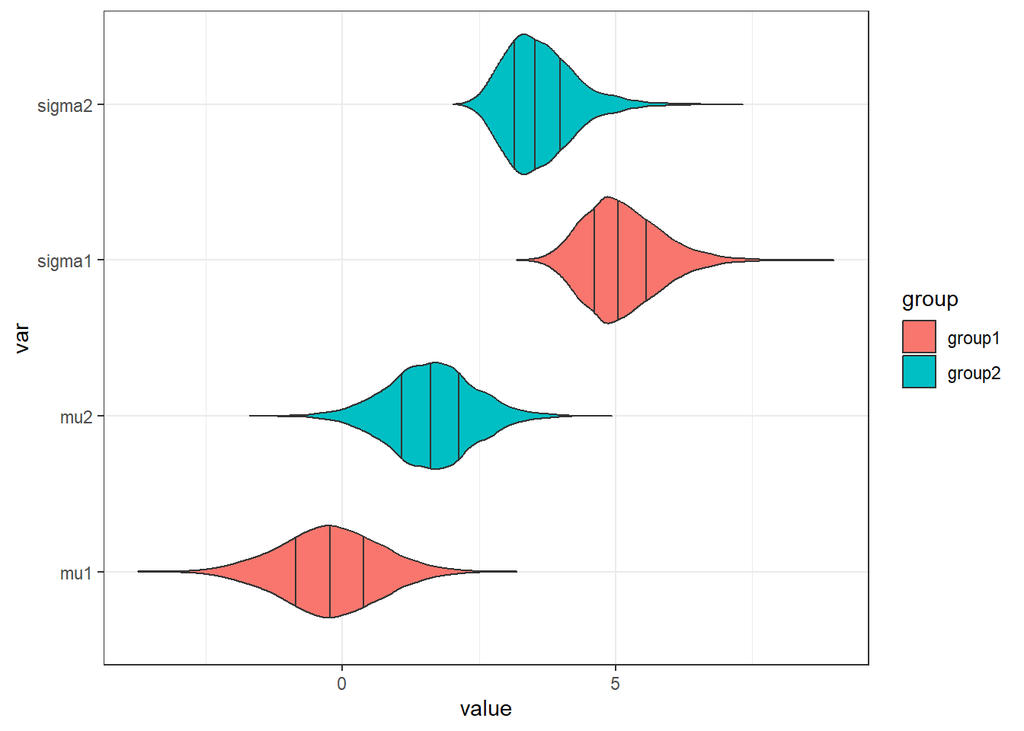

```r
draws_uneq |>
  pivot_longer(
    cols = c(mu1:sigma2),
    names_to = "var",
    values_to = "value"
  ) |>
  mutate(
    group = if_else(
      str_detect(var, pattern = "1"), "group1", "group2"
    )
  ) |>
  ggplot(aes(x = value, y = var, fill = group)) +
  geom_violin(draw_quantiles = c(0.25,0.5,0.75)) +
  theme_bw()
```